# Production Function Estimation and Extension

# Analysis of Estimated Elasticites

```python
# Analysis of Estimated Elasticites

profit_rate = (
    Data
    .groupby(["ind2d","year"])[["sale_D", "cogs_D","xsga_D"]]
    .sum()

    )

profit_rate['profit_rate'] = (profit_rate['sale_D'] -profit_rate['cogs_D'] - profit_rate['xsga_D']
                              )/ profit_rate['sale_D']


Delocker_elast_plots =  pd.merge(Delocker_elast,profit_rate,
                                 how='left',
                                 on=['year','ind2d'])

Delocker_elast_plots = Delocker_elast_plots.loc[
    (Delocker_elast_plots["year"] >= 1970) & (Delocker_elast_plots["year"] <= 2021)].copy()

#add industry names
naics2_map = {
    11: "Agriculture",
    21: "Mining & Oil",
    22: "Utilities",
    23: "Construction",
    31: "Mfg: Food/Textile",
    32: "Mfg: Chemicals/Plastics",
    33: "Mfg: Metals/Machinery",
    42: "Wholesale Trade",
    44: "Retail: Stores",
    45: "Retail: Nonstore",
    48: "Transport",
    49: "Warehousing",
    51: "Information",
    52: "Finance",
    53: "Real Estate",
    54: "Prof. Services",
    55: "Management",
    56: "Admin & Support",
    61: "Education",
    62: "Healthcare",
    71: "Arts & Entertainment",
    72: "Accommodation & Food",
    81: "Other Services",
    92: "Public Admin",
    99: "Other"
}

Delocker_elast_plots["industry_name"] = Delocker_elast_plots["ind2d"].map(naics2_map)

avg = (
    Delocker_elast_plots
     .groupby("industry_name")[["theta_WI1_ct_update", "theta_WI2_ct_update"]]
    .mean()
    )
```

## Compute scatterplot of average elastiities

In the below figure, I plot the average estimated COGS production elasticities under both the two input model (COGS, Capital) in the x axis, and the three input model (COGS, XSGA, Capital) on the y axis. If both models provided the same results, the elasticities would fall close to the 45 degree line, which I also include in the plot. As shown below, ths plot shows that XSGA is a confounding factor that biases the COGS elasticity upwards, as all the average values lie to the right of the 45 degree line.

Also, this plot shows that, regardless of the model selected, for an average increase in the use of materials that result in an increase of 1% in the Cost of Good Sold (i.e the company allocated 1% more budget to COGS) results in an average increase between 0.55% to about 0.82% in sales (under the extended model with SG&A)

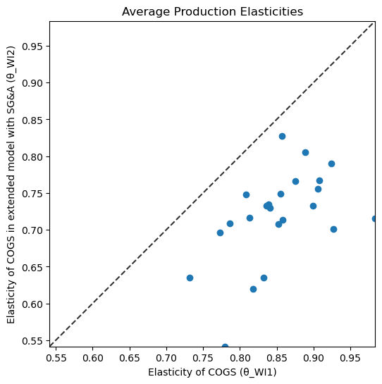

```
                         theta_WI1_ct_update  theta_WI2_ct_update
industry_name
Accommodation & Food                0.841001             0.730175
Admin & Support                     0.926873             0.701194
Agriculture                         0.856625             0.827836
Arts & Entertainment                0.983819             0.715711
Construction                        0.907885             0.767549
Education                           0.818034             0.619348
Finance                             0.857796             0.713387
Healthcare                          0.906066             0.755744
Information                         0.779578             0.541651
Mfg: Chemicals/Plastics             0.808359             0.747540
Mfg: Food/Textile                   0.924312             0.789714
Mfg: Metals/Machinery               0.852678             0.707716
Mining & Oil                        0.731751             0.635227
Other                               0.855267             0.748480
Other Services                      0.838727             0.734249
Prof. Services                      0.785833             0.708301
Real Estate                         0.832144             0.635094
Retail: Nonstore                    0.899675             0.732769
Retail: Stores                      0.813386             0.716557
Transport                           0.835681             0.733017
Utilities                           0.773288             0.696491
Warehousing                         0.875534             0.766604
Wholesale Trade                     0.888247             0.805094
```

```python
pyplot.figure(figsize=(6,6))
pyplot.scatter(avg['theta_WI1_ct_update'], avg['theta_WI2_ct_update'])
pyplot.xlabel("Elasticity of COGS (θ_WI1)")
pyplot.ylabel("Elasticity of COGS in extended model with SG&A (θ_WI2)")
pyplot.title("Average Production Elasticities")
# get axis limits (cover both x and y so they’re equal)
lims = [
    min(avg['theta_WI1_ct_update'].min(), avg['theta_WI2_ct_update'].min()),
    max(avg['theta_WI1_ct_update'].max(), avg['theta_WI2_ct_update'].max())
]

# draw 45-degree line
pyplot.plot(lims, lims, 'k--', alpha=0.8)

# set equal limits for x and y
pyplot.xlim(lims)
pyplot.ylim(lims)
pyplot.gca().set_aspect('equal', adjustable='box')

pyplot.show()
print(avg)
```